# Transportation airline data

Coach Skufca

2022-09-26

Experiment 1 includes summarizing, looking to match another report.

## Load Packages

```r
library(tidyverse)
library(here)
library(janitor)
```

## Load the BOT data

We take advantage of the `here` package to get the path to the file that we stored.

**NOTE** I use `clean_names` from the janitor package to get names formatted in a consistent and useable way.

```r
thisfile=here("data_raw","DL_SelectFields2022.zip")

df2022=read_csv(thisfile) %>% clean_names()
```

## Subsetting to data of interest

Let’s focus on flights from La Guardia (airport “LGA”) and eliminate cargo flights by requiring at leat 1 passenger.

```r
df1=df2022 %>% filter(passengers>0,origin=="LGA" | dest=="LGA")
```

We create a barchart as we have done before:

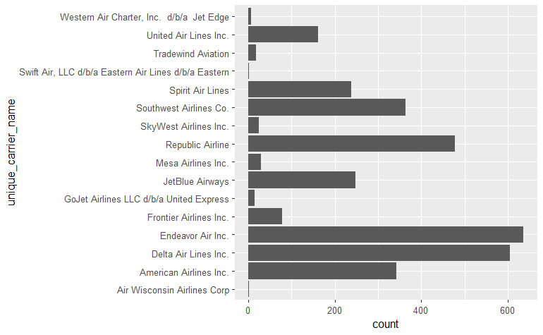

```r
df1 %>% ggplot(aes(unique_carrier_name)) + geom_bar() +coord_flip()
```

Nation wide?

[figure not shown]

```r
df2022 %>% filter(passengers>0) %>%  ggplot(aes(unique_carrier_name)) + geom_bar() +coord_flip()
```

```r
df2022 %>% filter(passengers>0) %>% pull(unique_carrier_name) %>% unique()
```

```
 [1] "Smokey Bay Air Inc."
 [2] "Boutique Air"
 [3] "Scott Air LLC dba Island Air Express"
 [4] "ADVANCED AIR, LLC"
 [5] "Delta Air Lines Inc."
 [6] "GoJet Airlines LLC d/b/a United Express"
 [7] "Star Marianas Air Inc."
 [8] "Endeavor Air Inc."
 [9] "Alaska Airlines Inc."
[10] "Horizon Air"
[11] "Delux Public Charter LLC"
[12] "Paklook Air, Inc d/b/a/ Airlift Alaska d/b/a/ Yute Commuter Service"
[13] "Tradewind Aviation"
[14] "Kenmore Air Harbor"
[15] "Southern Airways Express, dba Mokulele Airlines"
```

[output cut: 72 more lines]

### Summarize data

```r
df2=df2022 %>% filter(passengers>0) %>%
  group_by(carrier_name) %>%
  summarise(total_pass=sum(passengers),  num_flights=sum(departures_performed))

df2
```

| carrier_name | total_pass | num_flights |
| --- | --- | --- |
| 40-Mile Air | 274 | 326 |
| ADVANCED AIR, LLC | 29274 | 4822 |
| Air Charter, Inc d/b/a Air Flamenco | 12083 | 2299 |
| Air Excursions LLC | 3161 | 859 |
| Air Wisconsin Airlines Corp | 1389858 | 34070 |
| Alaska Airlines Inc. | 14027593 | 106396 |
| Alaska Central Express | 7678 | 850 |
| Allegiant Air | 8499776 | 58703 |
| American Airlines Inc. | 57034584 | 404441 |
| Ameristar Air Cargo | 4032 | 95 |

[output cut: 77 more lines]

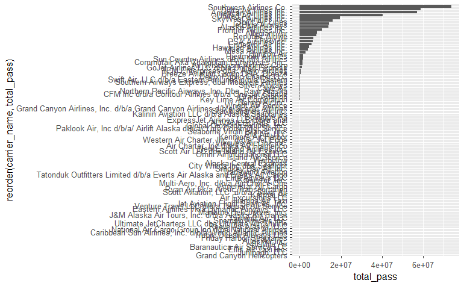

```r
df2 %>% ggplot(aes(reorder(carrier_name,total_pass),y=total_pass)) + geom_col() +coord_flip()
```

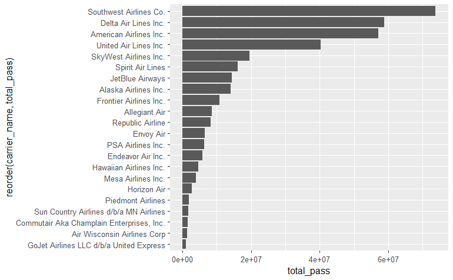

```r
df3=df2 %>% filter(total_pass>1e6)
df3 %>%   ggplot(aes(reorder(carrier_name,total_pass),y=total_pass)) + geom_col() +coord_flip()
```

```r
library(DataExplorer)
```

[figure not shown]

[figure not shown]

```r
library(explore)
```

```r
explore(df2)
```

```
Listening on http://127.0.0.1:4038
```

```
NA
```

# below here is not meaninful

** Take a look at the dataset and discover why counting rows is not going to give us a count of flights. **

The visualization we want is:

```r
df9 %>% ggplot(aes(month)) + geom_bar(aes(weight=departures_performed))
```

### A new visualization

Can you make a boxplot where the bar height is based on the number of passengers riding each month.

### Just because you can

Here is pretty, but not so useful plot.

```r
df9 %>% ggplot(aes(month,fill=carrier_name)) + geom_bar(aes(weight=departures_performed))
```

## Arrivals and departures from LGA

```r
df10=df2019 %>% filter(passengers>0,origin=="LGA" | dest=="LGA")

df10 %>% ggplot(aes(month)) + geom_bar(aes(weight=passengers))
```

```r
df11=df10 %>% select(month,passengers,seats, carrier_name, dest, origin)

df12=df10 %>% select(1:5, month, contains("id") )

df13=df11 %>% mutate(percent_loading = passengers/seats*100)

df13 %>% ggplot(aes(percent_loading)) +
  geom_histogram()+facet_wrap(~carrier_name,scales="free_y")
```

### Summarize data

```r
df15=df2019 %>% filter(passengers>0,origin=="LGA" | dest=="LGA") %>%
  group_by(month,carrier_name) %>%
  summarise(total_pass=sum(passengers),  num_flights=sum(departures_performed)) %>%
  mutate(average_pass_per_flight=total_pass/num_flights)


df15
df15 %>% ggplot(aes(x=month,y=average_pass_per_flight,color=carrier_name))+
  geom_line()
```

```r
df15_1=df2019 %>% filter(passengers>0,origin=="LGA" | dest=="LGA") %>%
  group_by(month,carrier_name) %>%
  summarise(total_seats=sum(seats),  num_flights=sum(departures_performed)) %>%
  mutate(average_seats_per_flight=total_seats/num_flights)


df15_1
df15_1 %>% ggplot(aes(x=month,y=average_seats_per_flight,color=carrier_name))+
  geom_line()
```

```r
df15=df2019 %>% filter(passengers>0,origin=="LGA" | dest=="LGA") %>%
  group_by(month) %>% mutate(percent_loading = passengers/seats*100) %>%
  summarise(loading=mean(percent_loading))
```

```r
df16=df2019 %>% filter(passengers>0,origin=="LGA" | dest=="LGA") %>%
  group_by(month,carrier_name) %>% mutate(percent_loading = passengers/seats*100) %>%
  summarise(loading=mean(percent_loading))
```

```r
df16 %>% ggplot(aes(x=month,y=loading,color=carrier_name))+
  geom_point()+
  theme_minimal()+geom_line()+
  theme(legend.position="bottom")
```

### cargo questions - which airport

```r
df17=df2019 %>% filter(origin_city_name=="New York, NY" ) %>%
  group_by(month,origin) %>%
  summarise(freight=sum(freight,na.rm = FALSE),passengers=sum(passengers),n=n())
df17
```